# ESM 204 HW #2

Ray Hunter and Elleri Griffiths

2023-04-24

```r
knitr::opts_chunk$set(echo = TRUE, warning = FALSE, message = FALSE)
library(tidyverse)
library(janitor)
library(here)
library(equatiomatic)
library(pracma)
```

### 1.

*For each campus, plot the marginal abatement cost data and estimate a linear regression model with zero intercept. These estimated linear regressions will be your estimates of the marginal abatement cost curve for each campus, which you will use for the remainder of this analysis. Write the equation for the marginal abatement cost curve for each campus.*

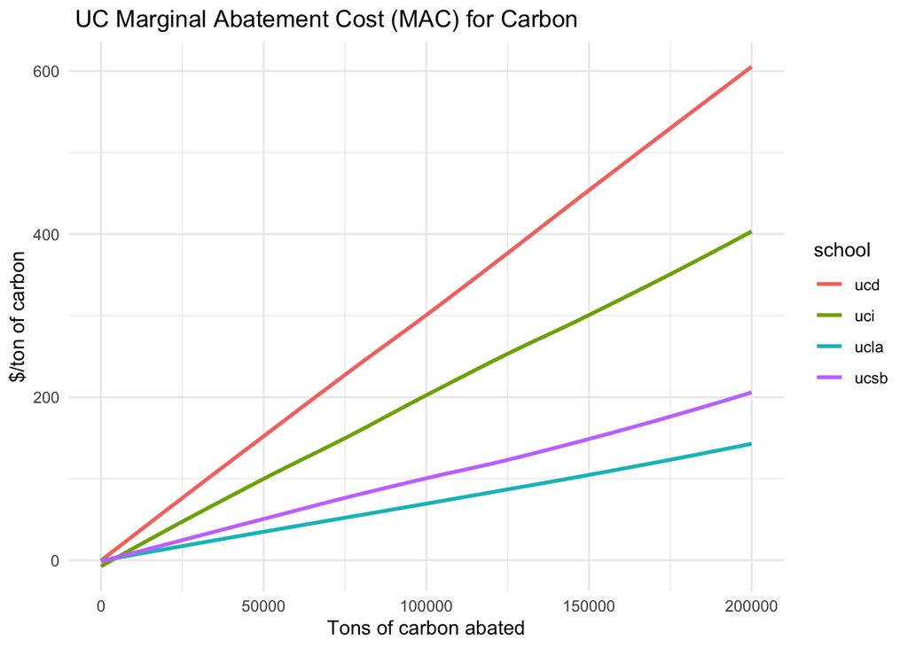

This graph shows the marginal abatement cost for each UC unvisersity. UCD has the highest MAC and UCLA has the lowest. This tells us that UCD pays the most for each increase in ton of carbon abaited and UCLA pays the least.

```r
#reading in data, cleaning it, and making longer
ab_data <- read.csv(here("CarbonUC.csv")) %>%
  clean_names() %>%
 pivot_longer(
   cols = c(ucsb:ucd),
   names_to = "school",
    values_to = "mca")

#creating a plot
ggplot(ab_data, aes( x = abatement, y = mca, color = school)) +
  geom_smooth(se=FALSE)+
  theme_minimal() +
  labs( title = " UC Marginal Abatement Cost (MAC) for Carbon ", y = "$/ton of carbon", x = "Tons of carbon abated")
```

```r
# creating linear models for mac for each school
ucsb_mac <- lm(mca~ 0 + abatement, data = filter(ab_data, school == "ucsb"))


ucla_mac <- lm(mca~ 0 + abatement, data = filter(ab_data, school == "ucla"))


uci_mac <- lm(mca~ 0 + abatement, data = filter(ab_data, school == "uci"))


ucd_mac <- lm(mca~ 0 + abatement, data = filter(ab_data, school == "ucd"))






#creating a function to calc abatement cost for ucla
ucsb_abate_func <- function(q) {
 p <-ucsb_mac[[1]]*q
return(p)
}



#creating a function to calc abatement cost for ucla
ucla_abate_func <- function(q) {
 p <-ucla_mac[[1]]*q
return(p)
}

#creating a function to calc abatement cost for uci
uci_abate_func <- function(q) {
 p <-uci_mac[[1]]*q
return(p)
}

#creating a function to calc abatement cost for ucd
ucd_abate_func <- function(q) {
 p <-ucd_mac[[1]]*q
return(p)
}
```

**UCSB**

```r
#showing the equations in pretty form
extract_eq(ucsb_mac, use_coefs = TRUE, coef_digits = 6)
```

$$\operatorname{\widehat{mca}} = 0.001004(\operatorname{abatement})$$

**UCLA**

```r
extract_eq(ucla_mac, use_coefs = TRUE, coef_digits = 6)
```

$$\operatorname{\widehat{mca}} = 0.000701(\operatorname{abatement})$$

**UCI**

```r
extract_eq(uci_mac, use_coefs = TRUE, coef_digits = 6)
```

$$\operatorname{\widehat{mca}} = 0.002008(\operatorname{abatement})$$

**UCD**

```r
extract_eq(ucd_mac, use_coefs = TRUE,coef_digits = 6)
```

$$\operatorname{\widehat{mca}} = 0.003024(\operatorname{abatement})$$

### 2.

*Using your estimated marginal abatement cost curves, together with the baseline emissions, derive each campus’ demand curve for carbon. In other words, how much would each campus be willing to pay to emit the first ton of carbon, the second ton of carbon, etc.2 Plot each campus’ demand curve for emissions on a single graph.*

```r
#creating a demand function that adds the willingness to pay of abatement for each university into the df
# A = Q_b - Q
# p = slope(A)
demand <- function(ab_data, dem, slope, Q_b, abatement) {
  ab_data[[dem]]<- slope*(Q_b - ab_data[[abatement]])
  ab_data

}



#applying the demand to each school using the slope from the mac linear models and the total pollution for each campus

ucsb_dem <- demand(filter(ab_data, school == "ucsb"), slope = ucsb_mac[[1]], "dem",  Q_b = 90000, "abatement")
ucla_dem <- demand(filter(ab_data, school == "ucla"), slope = ucla_mac[[1]], "dem",  Q_b = 250000, "abatement")
uci_dem <- demand(filter(ab_data, school == "uci"), slope = uci_mac[[1]], "dem",  Q_b = 100000, "abatement")
ucd_dem <- demand(filter(ab_data, school == "ucd"), slope = ucd_mac[[1]], "dem",  Q_b = 160000, "abatement")





#combining them into one df
uc_dem <- ucsb_dem %>%
  full_join(ucla_dem) %>%
  full_join(uci_dem) %>%
  full_join(ucd_dem) %>%
  arrange(abatement )
```

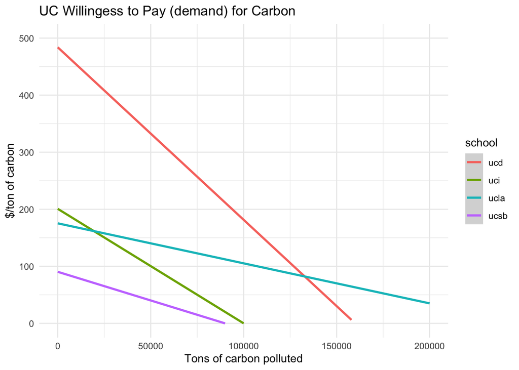

This graph shows the different demand curves for carbon pollution of each UC university. UCLA has the largest demand and UCSB has the shortest demand.

```r
#creating a graph of each university WTP
ggplot(uc_dem, aes(x= abatement, y = dem, color = school)) +
  geom_smooth() +
  labs( title = "UC Willingess to Pay (demand) for Carbon ", y = "$/ton of carbon", x = "Tons of carbon polluted") +
  ylim(0, 500) +
  theme_minimal()
```

#### Demand linear model equation

**UCSB**

```r
ucsb_dem_lm <- lm(dem ~ abatement, data = ucsb_dem)
extract_eq(ucsb_dem_lm, use_coefs = TRUE, coef_digits = 6)
```

$$\operatorname{\widehat{dem}} = 90.378126 -
0.001004(\operatorname{abatement})$$

**UCLA**

```r
ucla_dem_lm <- lm(dem ~ abatement, data = ucla_dem)
extract_eq(ucla_dem_lm, use_coefs = TRUE, coef_digits = 6)
```

$$\operatorname{\widehat{dem}} = 175.358687 -
0.000701(\operatorname{abatement})$$

**UCI**

```r
uci_dem_lm <- lm(dem ~ abatement, data = uci_dem)
extract_eq(uci_dem_lm, use_coefs = TRUE, coef_digits = 6)
```

$$\operatorname{\widehat{dem}} = 200.772888 -
0.002008(\operatorname{abatement})$$

**UCD**

```r
ucd_dem_lm <- lm(dem ~ abatement, data = ucd_dem)
extract_eq(ucd_dem_lm, use_coefs = TRUE, coef_digits = 6)
```

$$\operatorname{\widehat{dem}} = 483.862724 -
0.003024(\operatorname{abatement})$$

*Which campus is willing to pay the most for the first ton of carbon emissions?*

As seen in the demand curves for each school, UCD is willing to pay the most for the first ton of carbon at about $484 (the y intercept on the demand graph).

### 3.

*Here you will analyze three alternative interventions for reducing carbon emissions across these four campuses. Please answer the questions about each intervention listed below.*

#### a. Intervention #1: Carbon Tax:

```r
# make a function that finds Q from P
find_q <- function(a, p, b){
  q <- (a-p)/-b
  return(q)
}


#function to find the price given the quantity
find_p <- function(a, b, q){
  p <- a + b*q
  return(p)
}


#aply it to each school










###################### UCSB ######################
#how much would be emited?
ucsb_emit <- find_q(a = ucsb_dem_lm$coefficients[1], p = 50, b = ucsb_dem_lm$coefficients[2] )

#how much would be abated?
i1_ucsb_abate <- (90000 - ucsb_emit)

####################### UCLA  ######################################
#UCLA
#how much would be emited?
ucla_emit <- find_q(a = ucla_dem_lm$coefficients[1], p = 50, b = ucla_dem_lm$coefficients[2] )

#how much would be abated?
i1_ucla_abate <-(250000 - ucla_emit)


#######################  UCI  ######################################
#UCI
#how much would be emited?
uci_emit <- find_q(a = uci_dem_lm$coefficients[1], p = 50, b = uci_dem_lm$coefficients[2] )
#how much would be abated?
i1_uci_abate <- (100000 - uci_emit)


######################  UCD   #######################################
#how much would be emited?
ucd_emit <- find_q(a = ucd_dem_lm$coefficients[1], p = 50, b = ucd_dem_lm$coefficients[2] )
#how much would be abated?
i1_ucd_abate <- (160000 - ucd_emit)


######################  All UC   #######################################

uc_emit_tot <- ucsb_emit + ucla_emit + uci_emit + ucd_emit

uc_revenue <- uc_emit_tot*50
```

*Each campus must pay a tax of $50/ton for each ton of emissions. How much would each campus choose to emit? How much would each campus abate?*

When the price of carbon is $50 per ton:

**UCSB** will **emit 40,209.19** and **abate 49,790.81** tons of carbon.

**UCLA** will **emit 178,717.5** and **abate 71,282.47** tons of carbon.

**UCI** will **emit 75,096.24** and **abate 24,903.76** tons of carbon.

**UCD** will **emit 143,466.4** and **abate 16,533.62** tons of carbon.

*What is the total amount of emissions across all four campuses? How much tax revenue is generated?*

All of the UC’s combined would generate **437,489.3 tons** of carbon if each ton of carbon were taxed at $50. This translates into **$21,874,467 of tax revenue** generated.

#### b. Intervention #2: Carbon Ban:

```r
################### UCSB #########################
ucsb_0 <- .5*(90000)*ucsb_dem_lm$coefficients[1]
ucla_0 <- .5*(250000)*ucla_dem_lm$coefficients[1]
uci_0 <- .5*(100000)*uci_dem_lm$coefficients[1]
ucd_0 <- .5*(160000)*ucd_dem_lm$coefficients[1]
```

*Carbon emissions are banned at each campus. What is the total cost of this ban to each campus?*

The total cost of banning carbon at each campus would be:

**UCSB: $4,067,016**

**UCLA: $21,919,836**

**UCI: $10,038,644**

**UCD: $38,709,018**

#### c. Intervention #3: Cap without Trade:

```r
#################### abatement after cap #######################################

ucsb_abait <- 100000 - 90000
ucla_abait <- 100000 - 250000
uci_abait <- 100000 - 100000
ucd_abait <- 100000 - 160000


#################### price of MCA of last unit #######################################

#ucsb
ucsb_mca_p <- ucsb_abate_func( q= 0)

#ucla

ucla_mca_p <- ucla_abate_func( q= 150000)

#uci
uci_mca_p <- uci_abate_func(q= 0)

#ucd
ucd_mca_p <- ucd_abate_func( q= 60000)




#################### total cost of abaitment for each campus #############################




ucsb_ab_cost <- integrate(ucsb_abate_func, lower = 0, upper  = 0)


ucla_ab_cost <- integrate(ucla_abate_func, lower = 0, upper  = 150000)

uci_ab_cost <- integrate(uci_abate_func, lower = 0, upper  = 0)

ucd_ab_cost <- integrate(ucd_abate_func, lower = 0, upper  = 60000)
```

*Each campus is capped at 100,000 tons of carbon.*

*How much abatement would be required by each campus to comply with this cap?*

**UCSB: 0 tons**

**UCLA: 150,000 tons**

**UCI: 0 tons**

**UCD: 60,000 tons**

*What is the marginal cost of the last unit of abatement for each campus?*

**UCSB: $0**

**UCLA: $105.22**

**UCI: $0**

**UCD: $181.45**

*What is the total cost of abatement for each campus to comply with this new cap?*

**UCSB: $0**

**UCLA: $7,891,141**

**UCI: $0**

**UCD: $5,443,456**

#### d. Intervention #4: Cap with Trade:

```r
#making a new df creating the aggregate demand
trade_data <- data.frame(price = seq(0,500, length.out=101)) %>%

  #new colomn for ucsb finding the quantity demanded at each price
  mutate(Q_ucsb = pmax(0, find_q(a= ucsb_dem_lm$coefficients[[1]], p = price, b=ucsb_dem_lm$coefficients[[2]] ))) %>%
  mutate(Q_ucla = pmax(0, find_q(a= ucla_dem_lm$coefficients[[1]], p = price, b=ucla_dem_lm$coefficients[[2]] ))) %>%
  mutate(Q_uci = pmax(0, find_q(a= uci_dem_lm$coefficients[[1]], p = price, b=uci_dem_lm$coefficients[[2]] ))) %>%
  mutate(Q_ucd = pmax(0, find_q(a= ucd_dem_lm$coefficients[[1]], p = price, b=ucd_dem_lm$coefficients[[2]] ))) %>%

  #adding up each of the quantities demanded at each price
  mutate(Q_agg = Q_ucsb + Q_ucla + Q_uci + Q_ucd)




#finding the pstar at the total Qbar of 400000
pstar = stats::spline(x=trade_data$Q_agg, y=trade_data$price, xout=4e5)$y




#How much would each campus emit? use function find q to find how much the uc emits at pstar

ucsb_trade_dem <- find_q(a= ucsb_dem_lm$coefficients[[1]], p = pstar, b = ucsb_dem_lm$coefficients[[2]])


ucla_trade_dem <- find_q(a= ucla_dem_lm$coefficients[[1]], p = pstar, b = ucla_dem_lm$coefficients[[2]])


uci_trade_dem <- find_q(a= uci_dem_lm$coefficients[[1]], p = pstar, b = uci_dem_lm$coefficients[[2]])


ucd_trade_dem <- find_q(a= ucd_dem_lm$coefficients[[1]], p = pstar, b = ucd_dem_lm$coefficients[[2]])
```

*Suppose each campus is capped at 100,000 tons of carbon, but trade is allowed. With trade, total emissions will be 400,000 but some campuses may emit more or less than 100,000.*

*How much would each campus end up emitting after trade? For each campus, calculate whether they are a buyer or a seller of permits.*

Because each university is capped at 100,000 tons of carbon individually, they will be considered a **seller** if they demand less than 100,000 tons at the equilibrium price (p star) and they will be considered a **buyer** if their demand is more than 100,000 tons at equilibrium. After trading, each university will emit this much carbon.:

**UCSB carbon emissions: 28,722.86 tons (seller)**

**UCLA carbon emissions: 162,273.3 tons (buyer)**

**UCI carbon emissions: 69,351.15 tons (seller)**

**UCD carbon emissions: 139,652.2 tons (buyer)**

*What is the equilibrium trading price of carbon permits?*

The equilibrium price (p star) for the aggregate demand of pollution for all combined universities capped at 400,000 tons of carbon is **$61.53**.

### 4.

```r
#finding the pstar at the total Qbar of 350000
pstar2 = stats::spline(x=trade_data$Q_agg, y=trade_data$price, xout=350000)$y






# how much will it cost the philanthopist?

phil_cost <- (400000 - 350000)*pstar
```

*The central campus decides to go with the “Cap with Trade” approach (Scenario 3d above). An altruistic philanthropist buys 50,000 of the permits from the cap and trade market and retires them (i.e. not emit the carbon), so only 350,000 tons will be emitted.*

*What is the new trading price among the four campuses?*

The new trading price (p star) will be **$76.91** per ton of carbon for each of the universities after 50,000 of the credits are retired by the philanthropist. This leave 350,000 credits of carbon left in the market.

*How much will it cost the philanthropist to buy and retire these permits?*

It will cost the Philanthropist **$3,076,729** to buy the 50,000 permits.